# Equal_time_fastMNN velociraptor dynamical BOTH beige & white

Sarah Hazell Pickering

2024-08-28

Running with the read2only UMAPs, but the unspliced/spliced counts from the paired end mode (called count_no_introns). Subsetting so there’s the same number of cells per time point. This brings the focus of the trajectory analysis to the day1-day0 progression. Keeping equal white and beige cell numbers. Starting with 4000 variable genes, then filtering based on unspliced and spliced counts.

```r
module = "beige_vs_white"
method_name = "fastmnn"
model = "dynamical" #stochastic (fast) or dynamical (accurate)
dataname = paste0("bvw_",method_name,"_equal_time")
red_name = paste("PCA", sep=".", toupper(method_name))
load_data = T #loading data
subset_data = F

rmd_filename = paste0("bvw_",method_name,"_velociraptor_", model)
i_am(file.path("analysis", module, paste0(rmd_filename,".Rmd")))
```

```
## here() starts at /projects/imb-pkbphil/sp/sc_rnaseq/progenitor_scrnaseq
```

```r
odir = here("output", module, dataname)
uns_dir = here("data/cellranger/count_no_introns")
indir = here("output", module, "bvw_fastmnn")
```

```r
set.seed(8)
fig_dir = here("analysis", module, "figures", rmd_filename)
if (!dir.exists(fig_dir)) dir.create(fig_dir, recursive = TRUE)
knitr::opts_chunk$set(fig.path = paste0(fig_dir, "/"),
                      dev = c("png","pdf"))

if (!dir.exists(odir)) dir.create(odir, recursive = TRUE)
```

```r
theme_hp = theme_classic(base_size = 15) +
  theme(axis.line = element_line(linewidth = 0.25),
        axis.ticks = element_line(linewidth = 0.25),
        strip.background = element_blank())
theme_set(theme_hp)
prog_cols = c("#DA1819","#691A93","#EBB400" , "#434D51","#00AED1","#3AAD00","#FF7F00","#AC8AD0")
pal = c("#1F78B4","#85C2EA","#B3B3B3", "#F18486","#E31A1C")
clusters = clusters = MetBrewer::met.brewer("Redon", 12)
names(clusters) = 0:11
spectral = rev(RColorBrewer::brewer.pal(n = 11, name = 'Spectral'))
```

Load Seurat object

```r
if (subset_data){
  sbs = readRDS(here(indir, "10%_complete_analysis.rds"))
  Idents(sbs) = "initial_clusters"
} else {
  sbs = readRDS(here(indir,"complete_analysis.rds"))
  DefaultAssay(sbs) = "RNA"
}
sbs
```

```
## An object of class Seurat
## 38601 features across 44693 samples within 2 assays
## Active assay: RNA (36601 features, 2000 variable features)
##  3 layers present: data, counts, scale.data
##  1 other assay present: mnn.reconstructed
##  8 dimensional reductions calculated: pca, umap, tsne, initial.umap, initial.tsne, pca.fastmnn, umap.fastmnn, tsne.fastmnn
```

```r
Idents(sbs) = "cond.time"
table(Idents(sbs))
```

```
##
## white.day3 white.day1   asc.day0 beige.day1 beige.day3
##      11077       7637       7265       7637      11077
```

```r
day0 = WhichCells(sbs, idents="asc.day0")
cells_to_keep = c()
for (cond in c('white.day3','beige.day3','white.day1',"beige.day1")){
    cells = sample(WhichCells(sbs, idents = cond), size=3632)
    cells_to_keep = c(cells_to_keep, cells)
}

filt = subset(sbs, cells = c(day0,cells_to_keep))
table(Idents(filt))
```

```
##
## white.day3 white.day1   asc.day0 beige.day1 beige.day3
##       3632       3632       7265       3632       3632
```

```r
filt = FindVariableFeatures(filt, nfeatures = 4000)
```

```
## Finding variable features for layer counts
```

```r
variable.genes = VariableFeatures(filt)
orig.genes = VariableFeatures(sbs)
Idents(filt) = "initial_clusters"
summary(variable.genes %in% orig.genes)
```

```
##    Mode   FALSE    TRUE
## logical    2039    1961
```

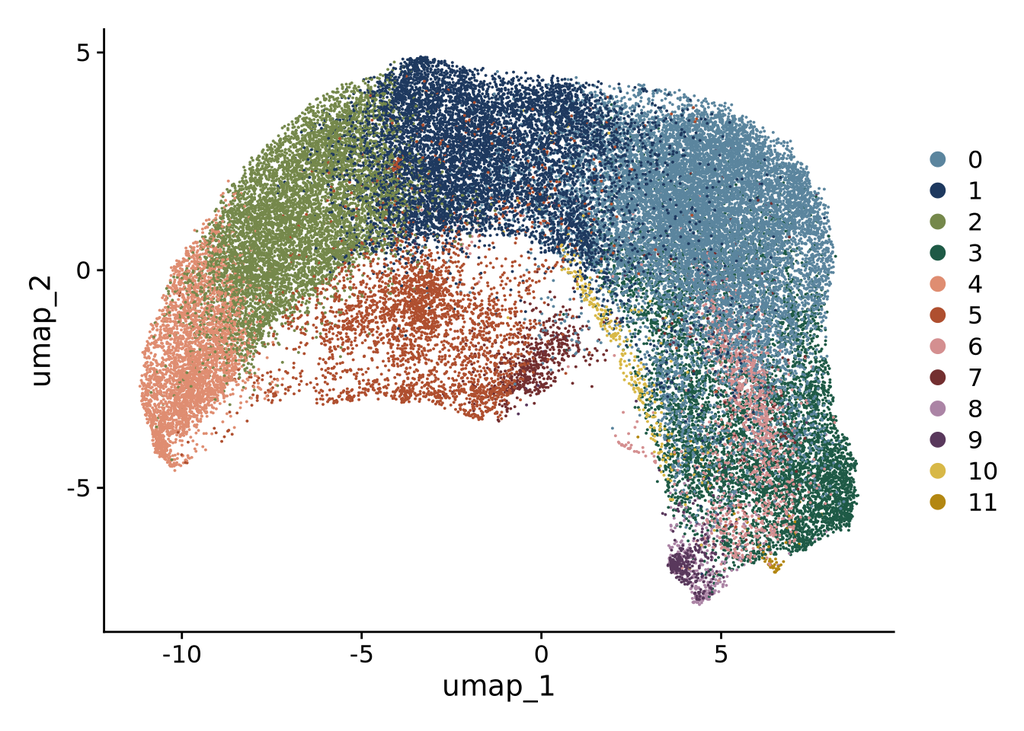

```r
DimPlot(filt, cols=clusters, reduction="umap")
```

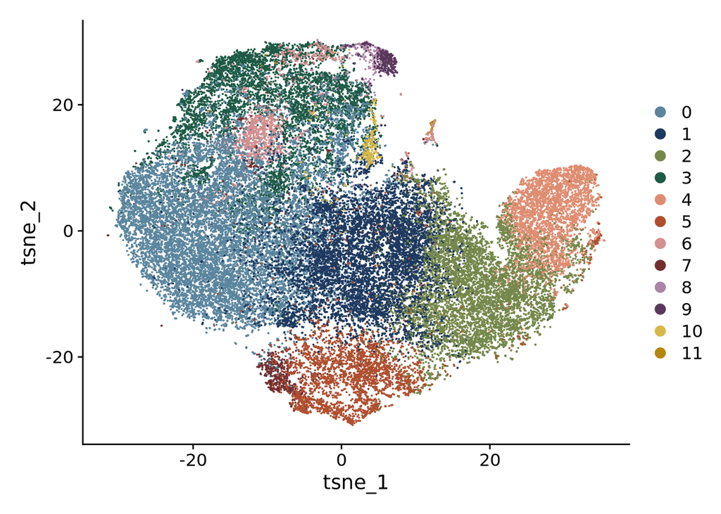

```r
DimPlot(filt, cols=clusters, reduction="tsne")
```

### Convert to SingleCell Experiment

```r
sce = as.SingleCellExperiment(filt, assay="RNA")
sce
```

```
## class: SingleCellExperiment
## dim: 36601 21793
## metadata(0):
## assays(3): counts logcounts scaledata
## rownames(36601): MIR1302-2HG FAM138A ... AC007325.4 AC007325.2
## rowData names(0):
## colnames(21793): asc.day0_AAACCTGAGAATAGGG-1
##   asc.day0_AAACCTGAGAGGGCTT-1 ... white.day3_TTTGTCATCAGTGCAT-1
##   white.day3_TTTGTCATCCATGAAC-1
## colData names(18): orig.ident nCount_RNA ... time.progen_clusters ident
## reducedDimNames(8): PCA UMAP ... UMAP.FASTMNN TSNE.FASTMNN
## mainExpName: RNA
## altExpNames(0):
```

```r
rowData(sce)
```

```
## DataFrame with 36601 rows and 0 columns
```

```r
head(rownames(sce))
```

```
## [1] "MIR1302-2HG" "FAM138A"     "OR4F5"       "AL627309.1"  "AL627309.3"
## [6] "AL627309.2"
```

```r
colData(sce)[1:7]
```

```
## DataFrame with 21793 rows and 7 columns
##                               orig.ident nCount_RNA nFeature_RNA     sample
##                                 <factor>  <numeric>    <numeric>   <factor>
## asc.day0_AAACCTGAGAATAGGG-1     asc_day0      33853         5322   asc_day0
## asc.day0_AAACCTGAGAGGGCTT-1     asc_day0      46014         6656   asc_day0
## asc.day0_AAACCTGAGATCGATA-1     asc_day0      33328         5355   asc_day0
## asc.day0_AAACCTGAGGTAGCTG-1     asc_day0      25327         4802   asc_day0
## asc.day0_AAACCTGAGGTGCTAG-1     asc_day0      31012         5750   asc_day0
## ...                                  ...        ...          ...        ...
## white.day3_TTTGTCACAGCGATCC-1 white_day3      16790         2817 white_day3
## white.day3_TTTGTCAGTTACCGAT-1 white_day3      11002         2388 white_day3
## white.day3_TTTGTCATCAGCTGGC-1 white_day3      18819         3391 white_day3
## white.day3_TTTGTCATCAGTGCAT-1 white_day3      12606         3254 white_day3
## white.day3_TTTGTCATCCATGAAC-1 white_day3      13288         3009 white_day3
##                                 condition        time         rep
##                               <character> <character> <character>
## asc.day0_AAACCTGAGAATAGGG-1           asc        day0        rep1
## asc.day0_AAACCTGAGAGGGCTT-1           asc        day0        rep1
## asc.day0_AAACCTGAGATCGATA-1           asc        day0        rep1
## asc.day0_AAACCTGAGGTAGCTG-1           asc        day0        rep1
## asc.day0_AAACCTGAGGTGCTAG-1           asc        day0        rep1
## ...                                   ...         ...         ...
## white.day3_TTTGTCACAGCGATCC-1       white        day3        rep1
## white.day3_TTTGTCAGTTACCGAT-1       white        day3        rep1
## white.day3_TTTGTCATCAGCTGGC-1       white        day3        rep1
## white.day3_TTTGTCATCAGTGCAT-1       white        day3        rep1
## white.day3_TTTGTCATCCATGAAC-1       white        day3        rep1
```

```r
rm(sbs)
rm(filt)
```

## Load our unspliced data

```r
samples = c(here(uns_dir, "white",c("white_day1","white_day1_rep2","white_day3")),
          here(uns_dir,"day0","day0_subjectS6"),
          here(uns_dir, "beige",c("beige_day1","beige_day1_rep2","beige_day3")))
sample_sfx = gsub(".*/", "", samples)

data_list = c()
for (i in 1:length(samples)){
  print(samples[i])
  loom = import(here(samples[i], "velocyto", paste0(sample_sfx [i],".loom")),
                type="SingleCellLoomExperiment")
  cell_id = paste0(gsub("_",".",sample_sfx[i]),"_")
  colnames(loom) = gsub(".*:",cell_id, gsub("x$","-1",colData(loom)$CellID))
  rownames(loom) = rowData(loom)$Gene
  rownames(loom)[duplicated(rownames(loom))] = paste0(rownames(loom)[duplicated(rownames(loom))], ".1")
  data_list = c(data_list,loom)
}
```

```
## [1] "/projects/imb-pkbphil/sp/sc_rnaseq/progenitor_scrnaseq/data/cellranger/count_no_introns/white/white_day1"
## [1] "/projects/imb-pkbphil/sp/sc_rnaseq/progenitor_scrnaseq/data/cellranger/count_no_introns/white/white_day1_rep2"
## [1] "/projects/imb-pkbphil/sp/sc_rnaseq/progenitor_scrnaseq/data/cellranger/count_no_introns/white/white_day3"
## [1] "/projects/imb-pkbphil/sp/sc_rnaseq/progenitor_scrnaseq/data/cellranger/count_no_introns/day0/day0_subjectS6"
## [1] "/projects/imb-pkbphil/sp/sc_rnaseq/progenitor_scrnaseq/data/cellranger/count_no_introns/beige/beige_day1"
## [1] "/projects/imb-pkbphil/sp/sc_rnaseq/progenitor_scrnaseq/data/cellranger/count_no_introns/beige/beige_day1_rep2"
## [1] "/projects/imb-pkbphil/sp/sc_rnaseq/progenitor_scrnaseq/data/cellranger/count_no_introns/beige/beige_day3"
```

```r
summary(data_list)
```

```
##      Length Class                    Mode
## [1,] 36601  SingleCellLoomExperiment S4
## [2,] 36601  SingleCellLoomExperiment S4
## [3,] 36601  SingleCellLoomExperiment S4
## [4,] 36601  SingleCellLoomExperiment S4
## [5,] 36601  SingleCellLoomExperiment S4
## [6,] 36601  SingleCellLoomExperiment S4
## [7,] 36601  SingleCellLoomExperiment S4
```

```r
loom = do.call(cbind, data_list)
loom
```

```
## class: SingleCellLoomExperiment
## dim: 36601 60141
## metadata(35): last_modified CreationDate ... velocyto.__version__
##   velocyto.logic
## assays(4): matrix ambiguous spliced unspliced
## rownames(36601): BX004987.1 AC145212.1 ... CDY1 TTTY3
## rowData names(6): Accession Chromosome ... Start Strand
## colnames(60141): white.day1_AAAGCAAGTCATATGC-1
##   white.day1_AAAGCAATCGTGGTCG-1 ... beige.day3_TTTGGTTTCCACGTTC-1
##   beige.day3_TTTGGTTTCTCGTATT-1
## colData names(1): CellID
## reducedDimNames(0):
## mainExpName: NULL
## altExpNames(0):
## rowGraphs(0): NULL
## colGraphs(0): NULL
```

```r
rowData(loom)
```

```
## DataFrame with 36601 rows and 6 columns
##                  Accession  Chromosome       End        Gene     Start
##                <character> <character> <integer> <character> <integer>
## BX004987.1 ENSG00000278704  GL000009.2     58376  BX004987.1     56140
## AC145212.1 ENSG00000277400  GL000194.1    115018  AC145212.1     53590
## MAFIP      ENSG00000274847  GL000194.1    115055       MAFIP     53594
## AC011043.1 ENSG00000276256  GL000195.1     49164  AC011043.1     42939
## AC011043.2 ENSG00000278198  GL000195.1    179372  AC011043.2    173872
## ...                    ...         ...       ...         ...       ...
## TTTY4B     ENSG00000235412           Y  24607025      TTTY4B  24570202
## BPY2B      ENSG00000183795           Y  24639207       BPY2B  24607560
## DAZ4       ENSG00000205916           Y  24907040        DAZ4  24833843
## CDY1       ENSG00000172288           Y  25624902        CDY1  25622162
## TTTY3      ENSG00000231141           Y  25733388       TTTY3  25728490
##                 Strand
##            <character>
## BX004987.1           -
## AC145212.1           -
## MAFIP                -
## AC011043.1           -
## AC011043.2           +
## ...                ...
## TTTY4B               +
## BPY2B                +
## DAZ4                 +
## CDY1                 +
## TTTY3                +
```

```r
colData(loom)
```

```
## DataFrame with 60141 rows and 1 column
##                                               CellID
##                                          <character>
## white.day1_AAAGCAAGTCATATGC-1 white_day1:AAAGCAAGT..
## white.day1_AAAGCAATCGTGGTCG-1 white_day1:AAAGCAATC..
## white.day1_AAAGATGTCCTCCTAG-1 white_day1:AAAGATGTC..
## white.day1_AAAGATGGTCGAATCT-1 white_day1:AAAGATGGT..
## white.day1_AACACGTTCGCGTTTC-1 white_day1:AACACGTTC..
## ...                                              ...
## beige.day3_TTTGGTTTCGCGATCG-1 beige_day3:TTTGGTTTC..
## beige.day3_TTTGTCACAAGTAGTA-1 beige_day3:TTTGTCACA..
## beige.day3_TTTGTCAAGTGGTAAT-1 beige_day3:TTTGTCAAG..
## beige.day3_TTTGGTTTCCACGTTC-1 beige_day3:TTTGGTTTC..
## beige.day3_TTTGGTTTCTCGTATT-1 beige_day3:TTTGGTTTC..
```

```r
assays(loom)[["unspliced"]]
```

```
## <36601 x 60141> matrix of class DelayedMatrix and type "integer":
##            white.day1_AAAGCAAGTCATATGC-1 ... beige.day3_TTTGGTTTCTCGTATT-1
## BX004987.1                             0   .                             0
## AC145212.1                             0   .                             0
##      MAFIP                             0   .                             0
## AC011043.1                             0   .                             0
## AC011043.2                             0   .                             0
##        ...                             .   .                             .
##     TTTY4B                             0   .                             0
##      BPY2B                             0   .                             0
##       DAZ4                             0   .                             0
##       CDY1                             0   .                             0
##      TTTY3                             0   .                             0
```

```r
loom$sample = gsub("_.*","", colnames(loom))
table(loom$sample)
```

```
##
##      beige.day1 beige.day1.rep2      beige.day3  day0.subjectS6      white.day1
##            2690            5266           13944            7553            6138
## white.day1.rep2      white.day3
##           12922           11628
```

### Combine objects

the handling of duplicate gene names is different between the two methods. The loom stores more gene information, so it doesn’t matter about the duplicates. seurat though doesn’t load the extra gene information

```r
summary(rownames(sce) %in% rownames(loom))
```

```
##    Mode    TRUE
## logical   36601
```

```r
summary(colnames(sce) %in% colnames(loom))
```

```
##    Mode   FALSE    TRUE
## logical    7265   14528
```

```r
head(colnames(sce)[!colnames(sce) %in% colnames(loom)] )
```

```
## [1] "asc.day0_AAACCTGAGAATAGGG-1" "asc.day0_AAACCTGAGAGGGCTT-1"
## [3] "asc.day0_AAACCTGAGATCGATA-1" "asc.day0_AAACCTGAGGTAGCTG-1"
## [5] "asc.day0_AAACCTGAGGTGCTAG-1" "asc.day0_AAACCTGAGTTGTAGA-1"
```

```r
# one cell missing because cellranger filtering
ncol(sce)
```

```
## [1] 21793
```

```r
colnames(loom) = gsub("day0.subjectS6", "asc.day0", colnames(loom))
sce = sce[,colnames(sce) %in% colnames(loom)]
ncol(sce)
```

```
## [1] 21793
```

```r
# filter cells from seurat analysis
filt = loom[rownames(sce),colnames(sce)]

assays(sce)[["unspliced"]] = assays(filt)[["unspliced"]]
assays(sce)[["spliced"]] = assays(filt)[["spliced"]]
sce
```

```
## class: SingleCellExperiment
## dim: 36601 21793
## metadata(0):
## assays(5): counts logcounts scaledata unspliced spliced
## rownames(36601): MIR1302-2HG FAM138A ... AC007325.4 AC007325.2
## rowData names(0):
## colnames(21793): asc.day0_AAACCTGAGAATAGGG-1
##   asc.day0_AAACCTGAGAGGGCTT-1 ... white.day3_TTTGTCATCAGTGCAT-1
##   white.day3_TTTGTCATCCATGAAC-1
## colData names(18): orig.ident nCount_RNA ... time.progen_clusters ident
## reducedDimNames(8): PCA UMAP ... UMAP.FASTMNN TSNE.FASTMNN
## mainExpName: RNA
## altExpNames(0):
```

```r
table(sce$sample)
```

```
##
##      white_day3 white_day1_rep2      white_day1        asc_day0      beige_day1
##            3632            2430            1202            7265            1202
## beige_day1_rep2      beige_day3
##            2430            3632
```

## Get some stats on the unspliced counts

Sum = total counts and detected = the number of detected features calculating for the unspliced

```r
sce$sample = factor(sce$sample, levels=c("beige_day3","beige_day1_rep2","beige_day1","asc_day0","white_day1","white_day1_rep2","white_day3"))
sce <- addPerCellQC(sce,
    subsets=list(Mito=grep("MT-", rownames(sce))),
    assay.type = "unspliced")
colData(sce)
```

```
## DataFrame with 21793 rows and 24 columns
##                               orig.ident nCount_RNA nFeature_RNA     sample
##                                 <factor>  <numeric>    <numeric>   <factor>
## asc.day0_AAACCTGAGAATAGGG-1     asc_day0      33853         5322   asc_day0
## asc.day0_AAACCTGAGAGGGCTT-1     asc_day0      46014         6656   asc_day0
## asc.day0_AAACCTGAGATCGATA-1     asc_day0      33328         5355   asc_day0
## asc.day0_AAACCTGAGGTAGCTG-1     asc_day0      25327         4802   asc_day0
## asc.day0_AAACCTGAGGTGCTAG-1     asc_day0      31012         5750   asc_day0
## ...                                  ...        ...          ...        ...
## white.day3_TTTGTCACAGCGATCC-1 white_day3      16790         2817 white_day3
## white.day3_TTTGTCAGTTACCGAT-1 white_day3      11002         2388 white_day3
## white.day3_TTTGTCATCAGCTGGC-1 white_day3      18819         3391 white_day3
## white.day3_TTTGTCATCAGTGCAT-1 white_day3      12606         3254 white_day3
## white.day3_TTTGTCATCCATGAAC-1 white_day3      13288         3009 white_day3
##                                 condition        time         rep percent.mt
##                               <character> <character> <character>  <numeric>
## asc.day0_AAACCTGAGAATAGGG-1           asc        day0        rep1   0.800520
## asc.day0_AAACCTGAGAGGGCTT-1           asc        day0        rep1   0.682401
## asc.day0_AAACCTGAGATCGATA-1           asc        day0        rep1   0.366059
## asc.day0_AAACCTGAGGTAGCTG-1           asc        day0        rep1   0.758084
## asc.day0_AAACCTGAGGTGCTAG-1           asc        day0        rep1   1.779956
## ...                                   ...         ...         ...        ...
## white.day3_TTTGTCACAGCGATCC-1       white        day3        rep1    0.51221
## white.day3_TTTGTCAGTTACCGAT-1       white        day3        rep1    3.30849
## white.day3_TTTGTCATCAGCTGGC-1       white        day3        rep1    1.43472
## white.day3_TTTGTCATCAGTGCAT-1       white        day3        rep1    3.92670
## white.day3_TTTGTCATCCATGAAC-1       white        day3        rep1    2.28025
##                               RNA_snn_res.0.5 seurat_clusters  cond.time
##                                      <factor>        <factor>   <factor>
## asc.day0_AAACCTGAGAATAGGG-1                 3               2   asc.day0
## asc.day0_AAACCTGAGAGGGCTT-1                 3               2   asc.day0
## asc.day0_AAACCTGAGATCGATA-1                 3               2   asc.day0
## asc.day0_AAACCTGAGGTAGCTG-1                 3               2   asc.day0
## asc.day0_AAACCTGAGGTGCTAG-1                 3               4   asc.day0
## ...                                       ...             ...        ...
## white.day3_TTTGTCACAGCGATCC-1               1               4 white.day3
## white.day3_TTTGTCAGTTACCGAT-1               5               5 white.day3
## white.day3_TTTGTCATCAGCTGGC-1               1               1 white.day3
## white.day3_TTTGTCATCAGTGCAT-1               1               1 white.day3
## white.day3_TTTGTCATCCATGAAC-1               2               5 white.day3
```

[output cut: 50 more lines]

```
## white.day3_TTTGTCATCAGTGCAT-1                0                     0
## white.day3_TTTGTCATCCATGAAC-1                0                     0
##                               subsets_Mito_percent     total
##                                          <numeric> <numeric>
## asc.day0_AAACCTGAGAATAGGG-1                      0      3838
## asc.day0_AAACCTGAGAGGGCTT-1                      0      5500
## asc.day0_AAACCTGAGATCGATA-1                      0      3675
## asc.day0_AAACCTGAGGTAGCTG-1                      0      2654
## asc.day0_AAACCTGAGGTGCTAG-1                      0      4950
## ...                                            ...       ...
## white.day3_TTTGTCACAGCGATCC-1                    0      1609
## white.day3_TTTGTCAGTTACCGAT-1                    0      1769
## white.day3_TTTGTCATCAGCTGGC-1                    0      2190
## white.day3_TTTGTCATCAGTGCAT-1                    0      1997
## white.day3_TTTGTCATCCATGAAC-1                    0      1557
```

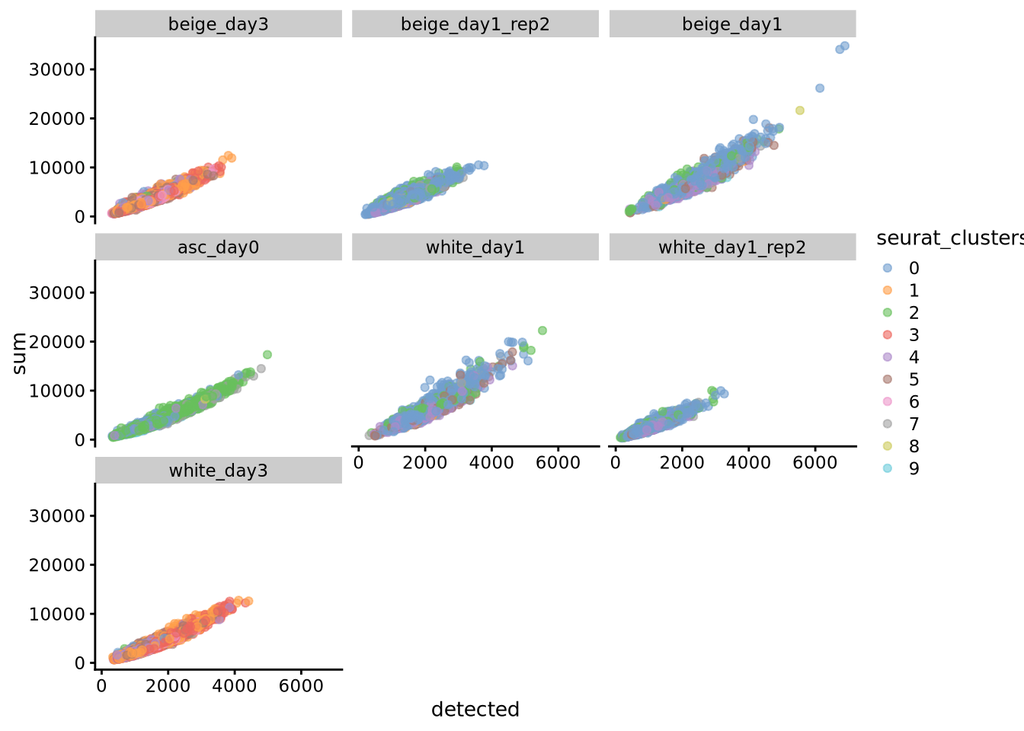

```r
plotColData(sce, y = "sum", x="detected", color_by="seurat_clusters", other_fields = "sample") + facet_wrap(~sample)
```

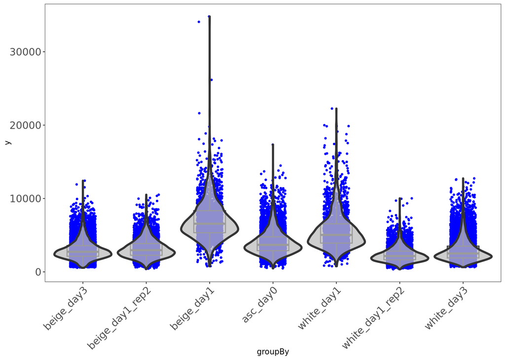

```r
singleCellTK::plotSCEViolin(sce, "colData", "sum", groupBy = "sample")
```

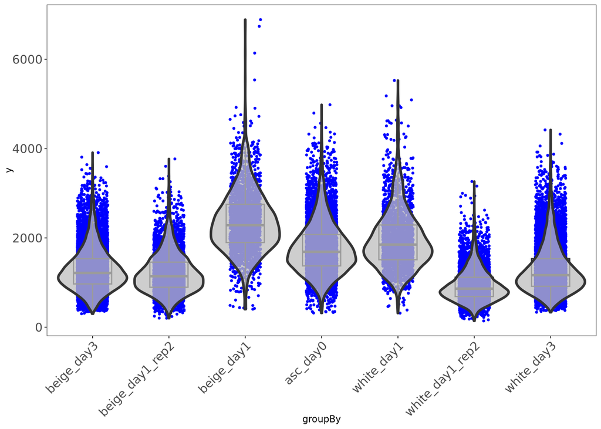

```r
singleCellTK::plotSCEViolin(sce, "colData", "detected", groupBy = "sample")
```

Okay interesting, the number of detected features drops for BOTH day1_rep2 and day3, even though day3 has been quantified in paired-end mode.

## Filter low expr genes

```r
nonzeroes = (assay(sce, "spliced") > 0 )* (assay(sce, "unspliced") > 0)
head(nonzeroes)
```

```
## <6 x 21793> matrix of class DelayedMatrix and type "integer":
##               asc.day0_AAACCTGAGAATAGGG-1 ... white.day3_TTTGTCATCCATGAAC-1
## MIR1302-2HG                             0   .                             0
## FAM138A                                 0   .                             0
## OR4F5                                   0   .                             0
## AL627309.1                              0   .                             0
## AL627309.3                              0   .                             0
## AL627309.2                              0   .                             0
```

```r
shared_counts = assay(sce, "spliced")*nonzeroes + assay(sce, "unspliced")*nonzeroes
head(shared_counts)
```

```
## <6 x 21793> matrix of class DelayedMatrix and type "integer":
##               asc.day0_AAACCTGAGAATAGGG-1 ... white.day3_TTTGTCATCCATGAAC-1
## MIR1302-2HG                             0   .                             0
## FAM138A                                 0   .                             0
## OR4F5                                   0   .                             0
## AL627309.1                              0   .                             0
## AL627309.3                              0   .                             0
## AL627309.2                              0   .                             0
```

```r
genes_to_keep = rowSums(shared_counts) > 20
summary(genes_to_keep)
```

```
##    Mode   FALSE    TRUE
## logical   24034   12567
```

```r
filt = sce[genes_to_keep,]
filt
```

```
## class: SingleCellExperiment
## dim: 12567 21793
## metadata(0):
## assays(5): counts logcounts scaledata unspliced spliced
## rownames(12567): LINC01409 LINC01128 ... AL592183.1 AC240274.1
## rowData names(0):
## colnames(21793): asc.day0_AAACCTGAGAATAGGG-1
##   asc.day0_AAACCTGAGAGGGCTT-1 ... white.day3_TTTGTCATCAGTGCAT-1
##   white.day3_TTTGTCATCCATGAAC-1
## colData names(24): orig.ident nCount_RNA ... subsets_Mito_percent total
## reducedDimNames(8): PCA UMAP ... UMAP.FASTMNN TSNE.FASTMNN
## mainExpName: RNA
## altExpNames(0):
```

```r
summary(variable.genes %in% rownames(filt))
```

```
##    Mode   FALSE    TRUE
## logical    1281    2719
```

```r
variable.genes = variable.genes[variable.genes %in% rownames(filt)]
reducedDimNames(sce)
```

```
## [1] "PCA"          "UMAP"         "TSNE"         "INITIAL.UMAP" "INITIAL.TSNE"
## [6] "PCA.FASTMNN"  "UMAP.FASTMNN" "TSNE.FASTMNN"
```

## Starting velocity analysis

Supplying variable genes and previously computed Integration reduction (acts as a PCA)

```r
velo.out = scvelo(sce, subset.row = variable.genes, use.dimred=red_name,
                  assay.X="counts", mode= model)
```

[output not shown]

```r
velo.out
```

```
## class: SingleCellExperiment
## dim: 2719 21793
## metadata(5): neighbors recover_dynamics velocity_params velocity_graph
##   velocity_graph_neg
## assays(10): X spliced ... velocity velocity_u
## rownames(2719): PLA2G2A MMP3 ... HSPE1 DDR2
## rowData names(18): fit_r2 fit_alpha ... velocity_genes varm
## colnames(21793): asc.day0_AAACCTGAGAATAGGG-1
##   asc.day0_AAACCTGAGAGGGCTT-1 ... white.day3_TTTGTCATCAGTGCAT-1
##   white.day3_TTTGTCATCCATGAAC-1
## colData names(8): velocity_self_transition root_cells ...
##   velocity_confidence velocity_confidence_transition
## reducedDimNames(1): X_pca
## mainExpName: NULL
## altExpNames(0):
```

```r
sce$velocity_pseudotime = velo.out$velocity_pseudotime
```

## pseuodtime

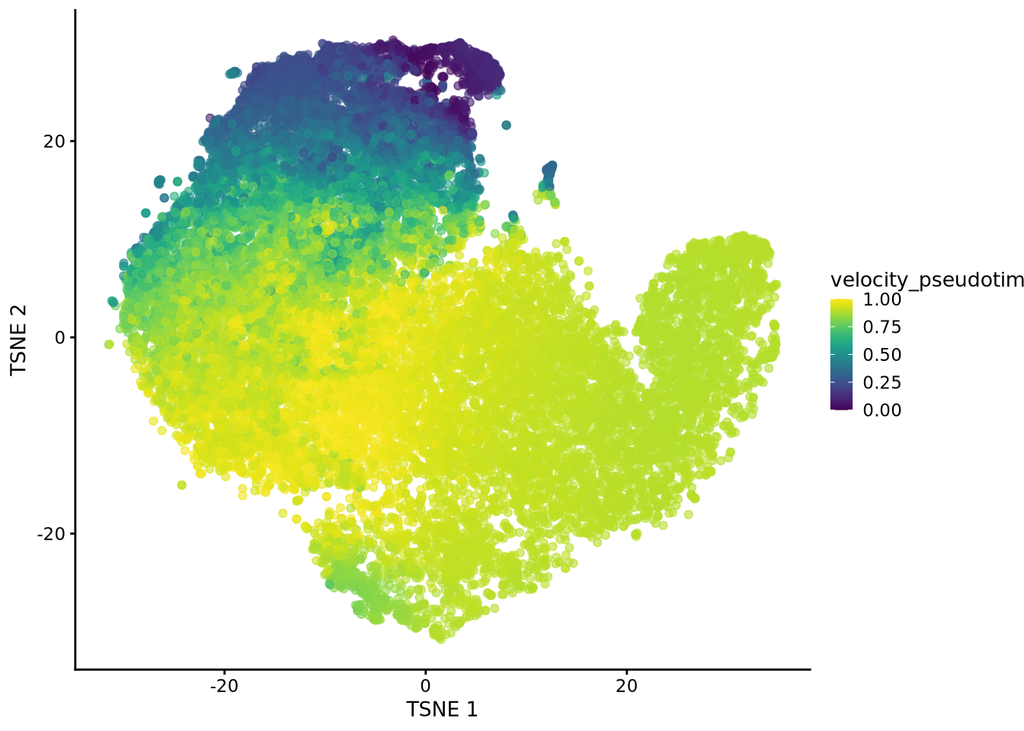

```r
plotTSNE(sce, color_by="velocity_pseudotime")
```

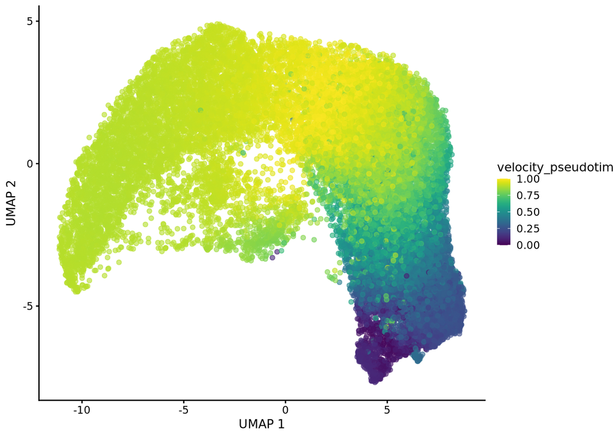

```r
plotUMAP(sce, color_by="velocity_pseudotime")
```

## Arrows on PCA

```r
embedded_pca <- embedVelocity(reducedDim(sce, red_name), velo.out)
```

```
## ℹ Using the 'X' assay as the X matrix
```

```
## computing velocity embedding
##     finished (0:00:12) --> added
##     'velocity_target', embedded velocity vectors (adata.obsm)
```

```r
dim(embedded_pca)
```

```
## [1] 21793    50
```

```r
reducedDim(sce, "PCA.SIMPLE") = reducedDim(sce, red_name)[,1:2]
grid.df <- gridVectors(sce, embedded_pca[,1:2], use.dimred = "PCA.SIMPLE")
colnames(grid.df) = gsub("mnn", "PC", colnames(grid.df))
head(grid.df)
```

```
##   start.PC_1  start.PC_2   end.PC_1    end.PC_2
## 1 -0.3944181 -0.17521195 -0.3949084 -0.16157592
## 2 -0.3193405 -0.08131870 -0.3159514 -0.07374529
## 3 -0.3489434 -0.15861513 -0.3554752 -0.15262954
## 4 -0.3339590 -0.15862461 -0.3409810 -0.15324560
## 5 -0.1862664 -0.07964679 -0.1810361 -0.08065287
## 6 -0.2306290 -0.04886340 -0.2216458 -0.04664660
```

```r
dim(grid.df)
```

```
## [1] 593   4
```

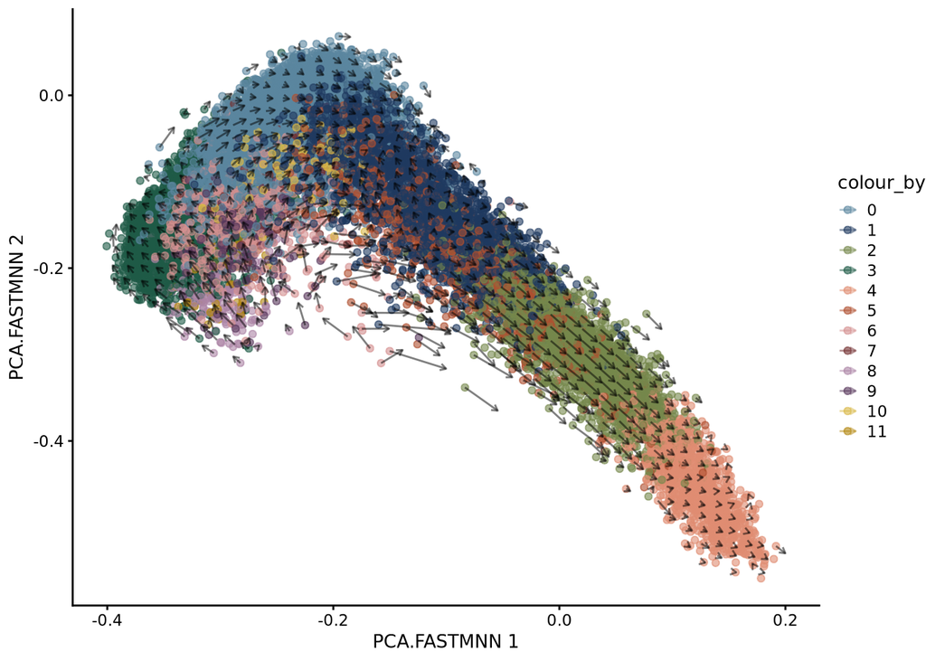

```r
plotReducedDim(sce, red_name,colour_by="initial_clusters") +
    geom_segment(data=grid.df, mapping=aes(x=start.PC_1, y=start.PC_2,
        xend=end.PC_1, yend=end.PC_2, colour=NULL), alpha=0.5,arrow=arrow(length=unit(0.05, "inches"))) &
  scale_colour_manual(values=clusters)
```

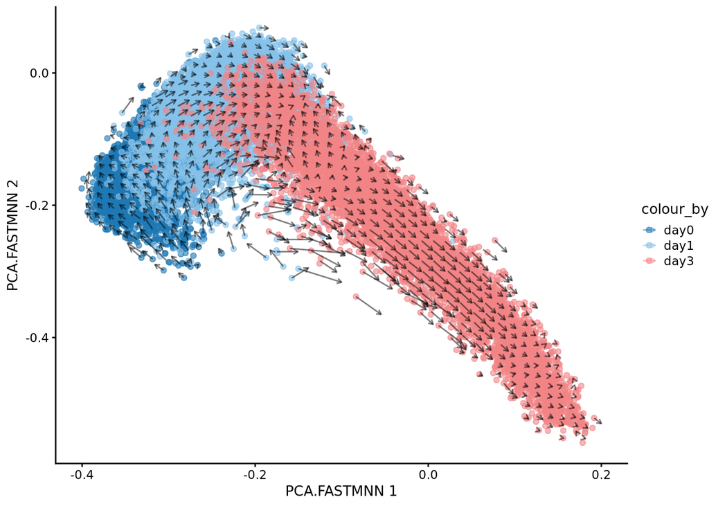

```r
plotReducedDim(sce, red_name,colour_by="time") +
    geom_segment(data=grid.df, mapping=aes(x=start.PC_1, y=start.PC_2,
        xend=end.PC_1, yend=end.PC_2, colour=NULL), alpha=0.5,arrow=arrow(length=unit(0.05, "inches"))) &
  scale_colour_manual(values=pal[c(1,2,4)])
```

## Arrows on UMAP

```r
embedded <- embedVelocity(reducedDim(sce, "UMAP"), velo.out)
```

```
## ℹ Using the 'X' assay as the X matrix
```

```
## computing velocity embedding
##     finished (0:00:08) --> added
##     'velocity_target', embedded velocity vectors (adata.obsm)
```

```r
dim(embedded)
```

```
## [1] 21793     2
```

```r
grid.df <- gridVectors(sce, embedded, use.dimred = "UMAP", resolution=40)
head(grid.df)
```

```
##   start.umap_1 start.umap_2 end.umap_1 end.umap_2
## 1     8.074123    -5.302984   8.409035 -4.9543976
## 2     6.577306    -3.085170   6.653166 -2.8889902
## 3     6.565264    -4.707156   6.882979 -4.5447124
## 4     5.071090    -3.761295   5.316006 -3.6222635
## 5     2.081422     1.892524   1.942746  1.5551438
## 6     4.063752     0.652483   3.699026  0.6911403
```

```r
dim(grid.df)
```

```
## [1] 1000    4
```

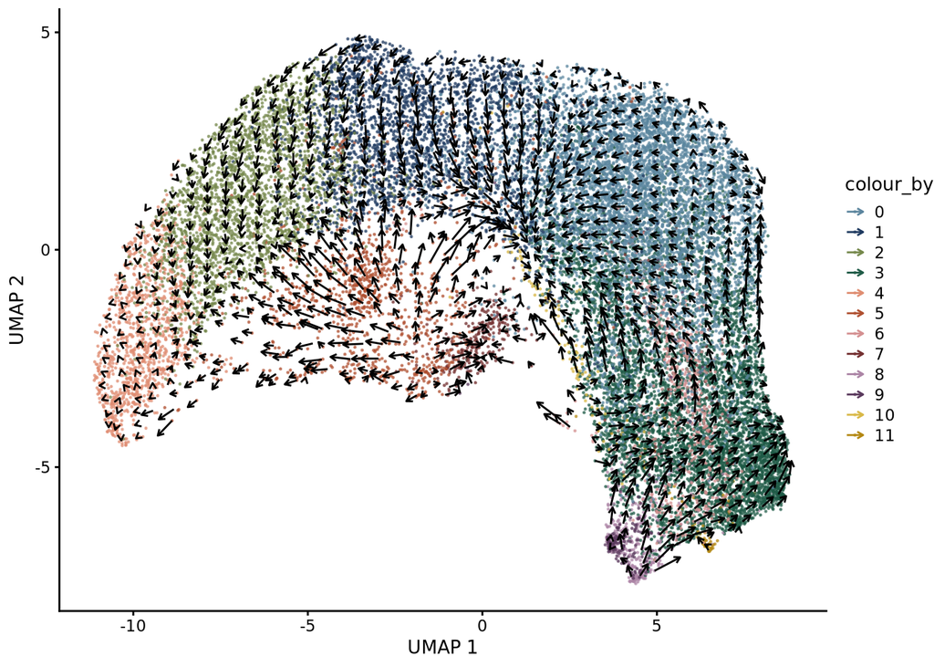

```r
if (subset_data){pt_size=1} else{pt_size=0.2}

plotReducedDim(sce, "UMAP",colour_by="initial_clusters", point_size=pt_size) +
    geom_segment(data=grid.df, mapping=aes(x=start.umap_1, y=start.umap_2,
        xend=end.umap_1, yend=end.umap_2, colour=NULL), width=1,arrow=arrow(length=unit(0.05, "inches"))) +
  scale_colour_manual(values=clusters)
```

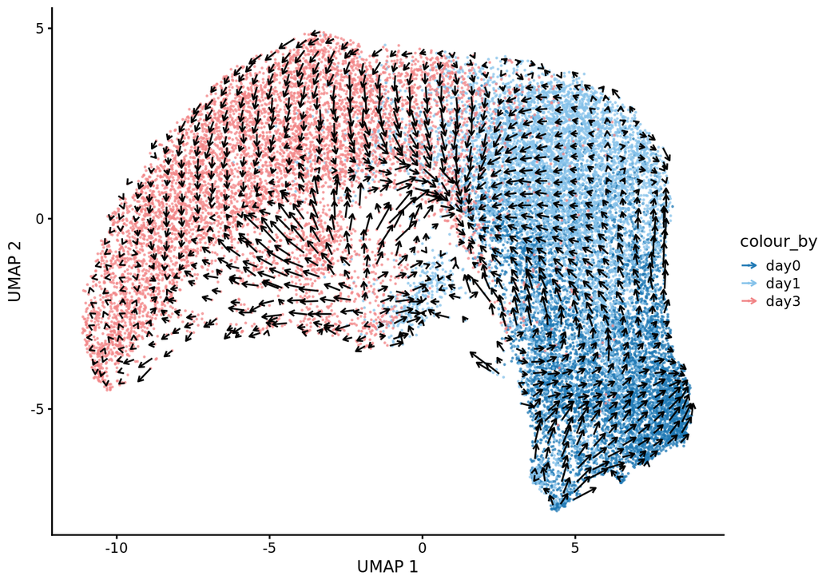

```r
plotReducedDim(sce, "UMAP",colour_by="time", point_size=pt_size) +
    geom_segment(data=grid.df, mapping=aes(x=start.umap_1, y=start.umap_2,
        xend=end.umap_1, yend=end.umap_2, colour=NULL), width=1,arrow=arrow(length=unit(0.05, "inches"))) +
  scale_colour_manual(values=pal[c(1,2,4)])
```

### Add progenitor clusters

```r
pro_clusters = "output/progenitors/integration_trial"
if (subset_data){
  filt = readRDS(here(pro_clusters, "10%_complete_analysis.rds"))
} else{
  filt = readRDS(here(pro_clusters, "complete_analysis.rds"))
}
filt
```

```
## An object of class Seurat
## 38601 features across 56638 samples within 2 assays
## Active assay: RNA (36601 features, 2000 variable features)
##  13 layers present: counts.S1, counts.S2, counts.S3, counts.S4, counts.S5, counts.S6, scale.data, data.S1, data.S2, data.S3, data.S4, data.S5, data.S6
##  1 other assay present: mnn.reconstructed
##  14 dimensional reductions calculated: pca, umap, tsne, initial.umap, initial.tsne, integrated.rpca, umap.rpca, rpca.tsne, integrated.harmony, umap.harmony, harmony.tsne, integrated.fastmnn, umap.fastmnn, fastmnn.tsne
```

```r
table(filt$rpca_clusters)
```

```
##
##     0     1     2     3     4     5     6
## 21710 18851  6320  5809  2086   974   888
```

```r
head(filt$rpca_clusters)
```

```
## day0.subjectS1_AAACCTGAGACTAGAT-1 day0.subjectS1_AAACCTGAGCTGTCTA-1
##                                 2                                 1
## day0.subjectS1_AAACCTGAGTACGACG-1 day0.subjectS1_AAACCTGCAAACTGCT-1
##                                 1                                 1
## day0.subjectS1_AAACCTGCAAGGCTCC-1 day0.subjectS1_AAACCTGCACAAGTAA-1
##                                 2                                 2
## Levels: 0 1 2 3 4 5 6
```

```r
tail(filt$rpca_clusters)
```

```
## day0.subjectS6_TTTGTCAAGTACGCGA-1 day0.subjectS6_TTTGTCAAGTACGTAA-1
##                                 1                                 2
## day0.subjectS6_TTTGTCAAGTAGGCCA-1 day0.subjectS6_TTTGTCACACGGCCAT-1
##                                 4                                 3
## day0.subjectS6_TTTGTCATCACGGTTA-1 day0.subjectS6_TTTGTCATCCGCTGTT-1
##                                 3                                 0
## Levels: 0 1 2 3 4 5 6
```

```r
pro_clusters = filt$rpca_clusters
names(pro_clusters) = gsub("day0.subjectS6","asc.day0",names(pro_clusters))
head(pro_clusters[colnames(sce)])
```

```
## asc.day0_AAACCTGAGAATAGGG-1 asc.day0_AAACCTGAGAGGGCTT-1
##                           0                           1
## asc.day0_AAACCTGAGATCGATA-1 asc.day0_AAACCTGAGGTAGCTG-1
##                           0                           0
## asc.day0_AAACCTGAGGTGCTAG-1 asc.day0_AAACCTGAGTTGTAGA-1
##                           2                           2
## Levels: 0 1 2 3 4 5 6
```

```r
sce$progen_clusters = pro_clusters[colnames(sce)]
table(sce$progen_clusters, useNA="ifany")
```

```
##
##     0     1     2     3     4     5     6  <NA>
##  2889  2401   637   653   364   168   103 14578
```

```r
sce$if_progen_cluster = paste0("w",sce$initial_clusters)
sce$if_progen_cluster[!is.na(sce$progen_clusters)] = paste0("p",sce$progen_clusters[!is.na(sce$progen_clusters)])
table(sce$if_progen_cluster, useNA="ifany")
```

```
##
##   p0   p1   p2   p3   p4   p5   p6   w0   w1  w10   w2   w3   w4   w5   w6   w7
## 2889 2401  637  653  364  168  103 6063 2604  107 2430   43 1106 1086  609  351
##   w8   w9
##    7  172
```

```r
sce$time.progen_clusters = sce$time
sce$time.progen_clusters[!is.na(sce$progen_clusters)] = paste0("p",sce$progen_clusters[!is.na(sce$progen_clusters)])
table(sce$time.progen_clusters)
```

```
##
## day0 day1 day3   p0   p1   p2   p3   p4   p5   p6
##   50 7264 7264 2889 2401  637  653  364  168  103
```

```r
rm(filt)
```

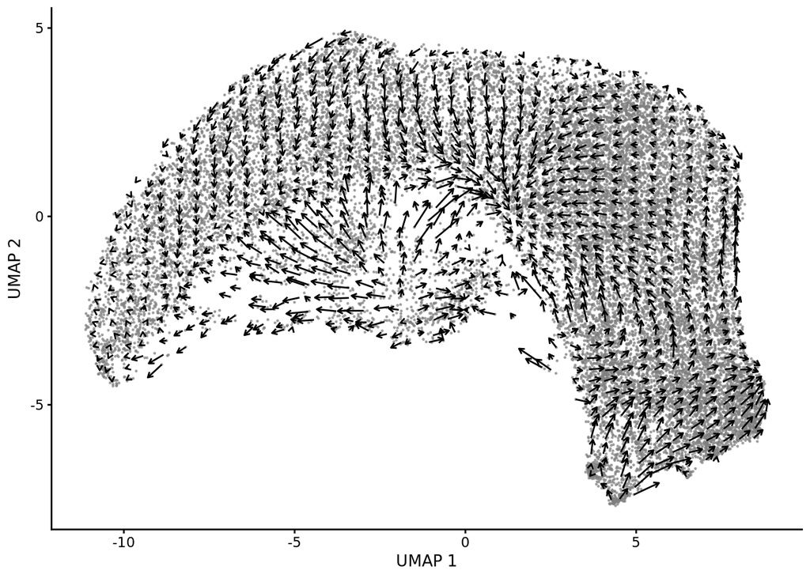

```r
plotReducedDim(sce, "UMAP",colour_by="time.progen_clusters", point_size=pt_size) +
    geom_segment(data=grid.df, mapping=aes(x=start.umap_1, y=start.umap_2,
        xend=end.umap_1, yend=end.umap_2, colour=NULL), width=1,arrow=arrow(length=unit(0.05, "inches"))) +
  scale_colour_manual(values=c(pal[1:3],clusters[c(1:4,6:14)]))
```

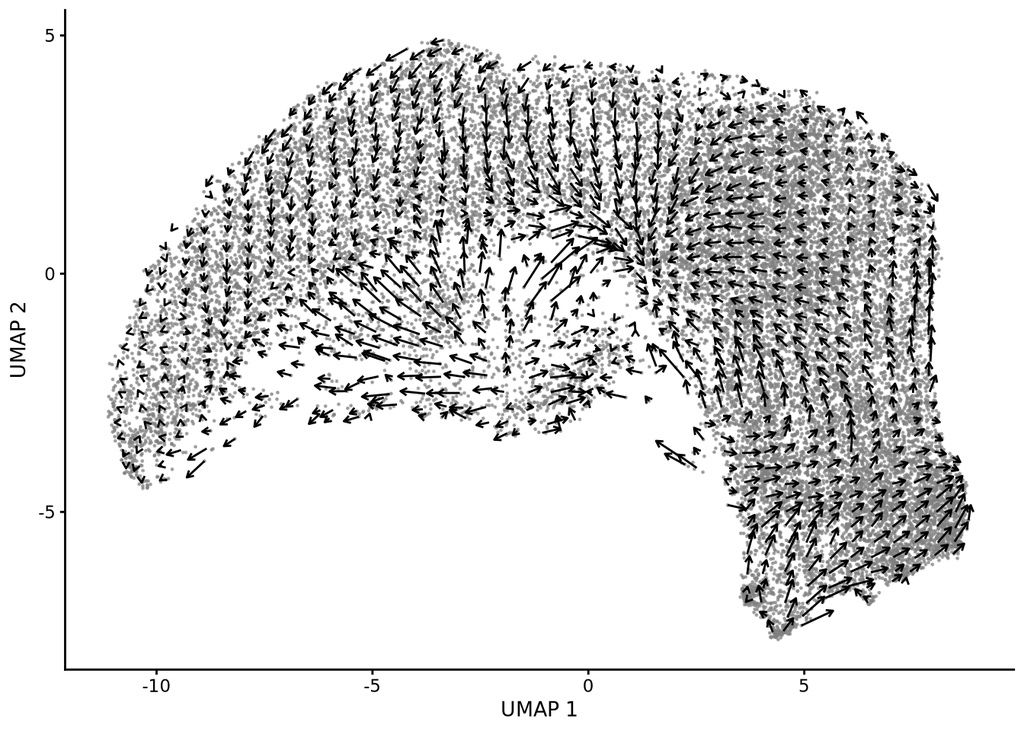

```r
plotReducedDim(sce, "UMAP",colour_by="if_progen_cluster", point_size=pt_size) +
    geom_segment(data=grid.df, mapping=aes(x=start.umap_1, y=start.umap_2,
        xend=end.umap_1, yend=end.umap_2, colour=NULL), width=1,arrow=arrow(length=unit(0.05, "inches"))) +
  scale_colour_manual(values=c(prog_cols,clusters[c(1:4,6:14)]))
```

## poking around the output object

```r
colnames(colData(velo.out))
```

```
## [1] "velocity_self_transition"       "root_cells"
## [3] "end_points"                     "velocity_pseudotime"
## [5] "latent_time"                    "velocity_length"
## [7] "velocity_confidence"            "velocity_confidence_transition"
```

```r
names(rowData(velo.out))
```

```
##  [1] "fit_r2"                "fit_alpha"             "fit_beta"
##  [4] "fit_gamma"             "fit_t_"                "fit_scaling"
##  [7] "fit_std_u"             "fit_std_s"             "fit_likelihood"
## [10] "fit_u0"                "fit_s0"                "fit_pval_steady"
## [13] "fit_steady_u"          "fit_steady_s"          "fit_variance"
## [16] "fit_alignment_scaling" "velocity_genes"        "varm"
```

I see a column here named root_cells. How does scvelo select root cells?  
velocity confidence, cool, but confidence_transition?

Then we have stuff calculated per gene; like alpha, beta & gamma; fit_steady, fit_likelihood

```r
summary(velo.out$root_cells)
```

```
##     Min.  1st Qu.   Median     Mean  3rd Qu.     Max.
## 0.000000 0.001924 0.011803 0.090380 0.077334 1.000000
```

```r
summary(velo.out$end_points)
```

```
##     Min.  1st Qu.   Median     Mean  3rd Qu.     Max.
## 0.000000 0.008655 0.053546 0.164738 0.225317 1.000000
```

```r
str(metadata(velo.out))
```

```
## List of 5
##  $ neighbors         :List of 4
##   ..$ connectivities_key: chr "connectivities"
##   ..$ distances_key     : chr "distances"
##   ..$ indices           : num [1:21793, 1:30] 0 1 2 3 4 5 6 7 8 9 ...
##   ..$ params            :List of 4
##   .. ..$ n_neighbors: int 30
##   .. ..$ method     : chr "umap"
##   .. ..$ metric     : chr "euclidean"
##   .. ..$ n_pcs      : NULL
##  $ recover_dynamics  :List of 2
##   ..$ fit_connected_states: logi TRUE
##   ..$ use_raw             : logi FALSE
##  $ velocity_params   :List of 5
##   ..$ fit_offset         : logi FALSE
##   ..$ mode               : chr "dynamical"
##   ..$ mode_neighbors     : chr "distances"
##   ..$ n_recurse_neighbors: int 2
##   ..$ perc               : int [1:2] 5 95
##  $ velocity_graph    :Formal class 'dgRMatrix' [package "Matrix"] with 6 slots
##   .. ..@ p       : int [1:21794] 0 56 209 494 719 1162 1356 1535 1719 1929 ...
##   .. ..@ j       : int [1:4456128] 57 170 211 234 354 482 833 892 1125 1347 ...
##   .. ..@ Dim     : int [1:2] 21793 21793
##   .. ..@ Dimnames:List of 2
##   .. .. ..$ : NULL
##   .. .. ..$ : NULL
##   .. ..@ x       : num [1:4456128] 0.53 0.197 0.264 0.63 0.589 ...
##   .. ..@ factors : list()
##  $ velocity_graph_neg:Formal class 'dgRMatrix' [package "Matrix"] with 6 slots
##   .. ..@ p       : int [1:21794] 0 282 519 585 679 705 1070 1167 1367 1446 ...
##   .. ..@ j       : int [1:4209748] 12 55 74 81 94 114 117 186 227 251 ...
##   .. ..@ Dim     : int [1:2] 21793 21793
##   .. ..@ Dimnames:List of 2
##   .. .. ..$ : NULL
##   .. .. ..$ : NULL
##   .. ..@ x       : num [1:4209748] -0.749 -0.563 -0.812 -0.851 -0.591 ...
##   .. ..@ factors : list()
```

## Velocity confidence and length

confidence = coherence of velocity directions  
length = speed of transcription between cells = roughly arrow length

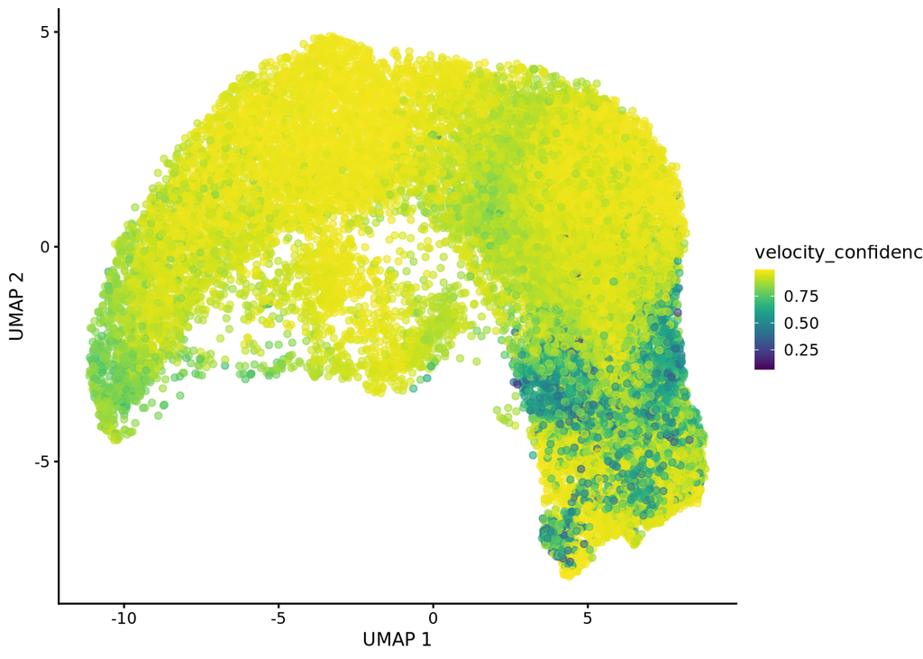

```r
sce$velocity_confidence = velo.out$velocity_confidence
sce$velocity_length = velo.out$velocity_length
plotReducedDim(sce, "UMAP",color_by="velocity_confidence", )
```

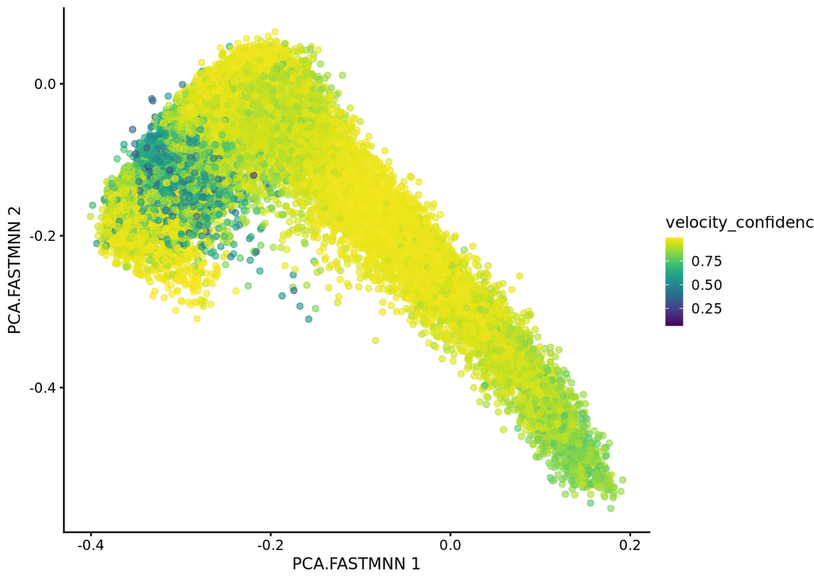

```r
plotReducedDim(sce, red_name,color_by="velocity_confidence", )
```

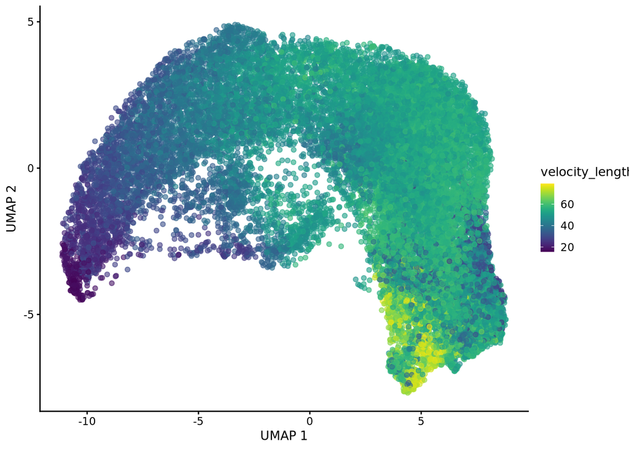

```r
plotReducedDim(sce, "UMAP",color_by="velocity_length" )
```

## Velocity stream plots

Error in `plotVelocityStream()`: ! use.dimred %in% reducedDimNames(sce) is not TRUE so not running this one

```r
colnames(reducedDim(sce, "UMAP"))
```

```
## [1] "umap_1" "umap_2"
```

```r
str(embedded)
```

```
##  num [1:21793, 1:2] 0.113 0.464 0.252 0.533 0.147 ...
```

```r
colnames(reducedDim(sce, "UMAP")) = c("V1","V2")
str(embedded)
```

```
##  num [1:21793, 1:2] 0.113 0.464 0.252 0.533 0.147 ...
```

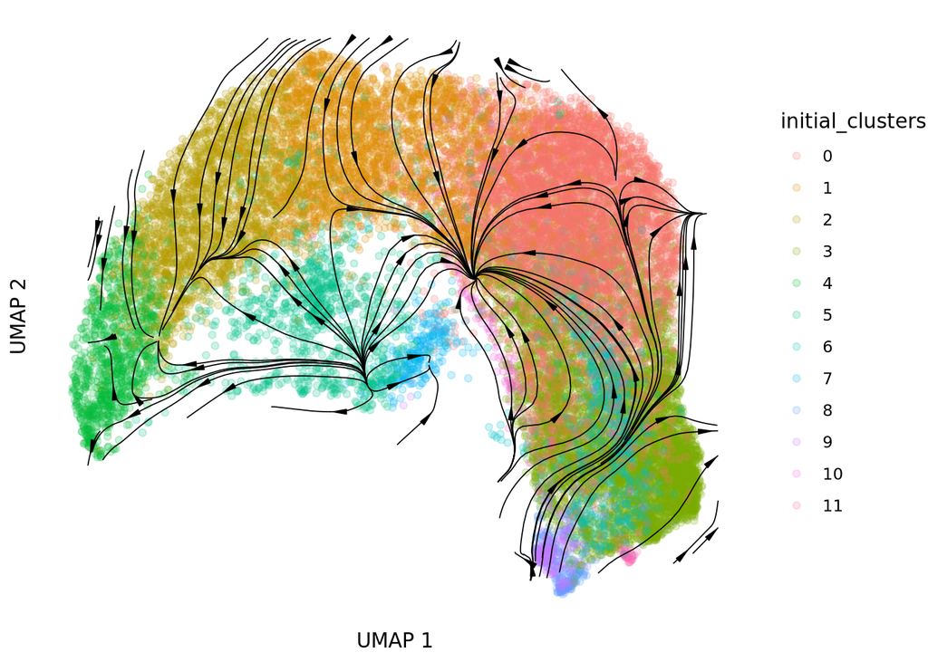

```r
plotVelocityStream(sce, embedded, use.dimred="UMAP",
                   color_by = "initial_clusters",grid.resolution=20,
                   stream.L = 10,
                   arrow.angle = 10, arrow.length = 0.5)
```

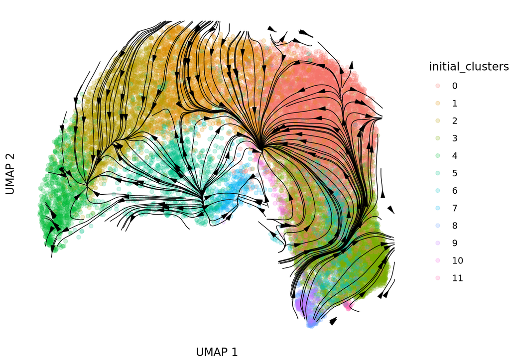

```r
plotVelocityStream(sce, embedded, use.dimred="UMAP",
                   color_by = "initial_clusters",grid.resolution=30,
                   stream.L = 8,
                   arrow.angle = 15, arrow.length = 0.5)
```

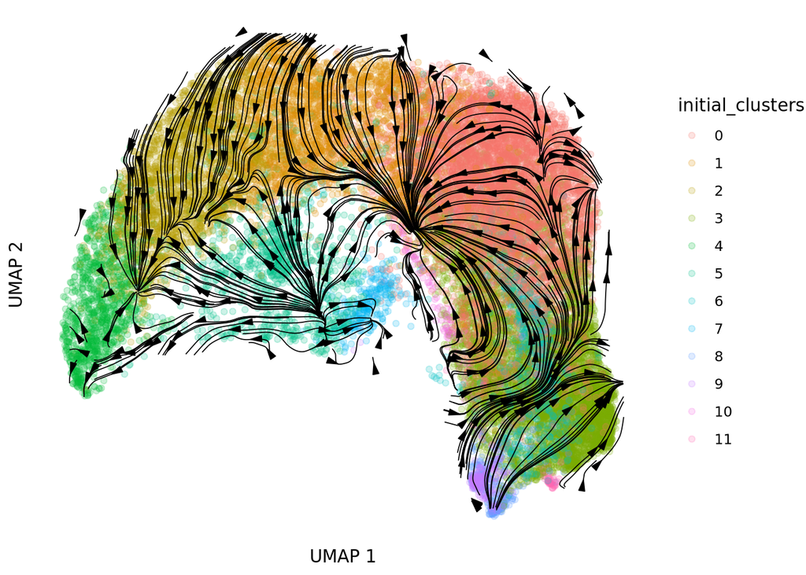

```r
plotVelocityStream(sce, embedded, use.dimred="UMAP",
                   color_by = "initial_clusters",grid.resolution=40,
                   stream.L = 5,
                   arrow.angle = 15, arrow.length = 0.5)
```

```r
if (subset_data == F){
  saveRDS(sce, file = here(odir, paste0(model, "_velocity_scexperiment.rds")))
  saveRDS(velo.out, file = here(odir,paste0(model, "_velocity_output.rds")))

} else if (subset_data){
  saveRDS(sce, file = here(odir, paste0("10%_subset_", model, "_velocity_scexperiment.rds")))
  saveRDS(velo.out, file = here(odir, paste0("10%_subset_", model, "_velocity_output.rds")))
}
```